# Project Foundations for Data Science: FoodHub Data Analysis

**Marks: 60**

### Context

The number of restaurants in New York is increasing day by day. Lots of students and busy professionals rely on those restaurants due to their hectic lifestyles. Online food delivery service is a great option for them. It provides them with good food from their favorite restaurants. A food aggregator company FoodHub offers access to multiple restaurants through a single smartphone app.

The app allows the restaurants to receive a direct online order from a customer. The app assigns a delivery person from the company to pick up the order after it is confirmed by the restaurant. The delivery person then uses the map to reach the restaurant and waits for the food package. Once the food package is handed over to the delivery person, he/she confirms the pick-up in the app and travels to the customer's location to deliver the food. The delivery person confirms the drop-off in the app after delivering the food package to the customer. The customer can rate the order in the app. The food aggregator earns money by collecting a fixed margin of the delivery order from the restaurants.

### Objective

The food aggregator company has stored the data of the different orders made by the registered customers in their online portal. They want to analyze the data to get a fair idea about the demand of different restaurants which will help them in enhancing their customer experience. Suppose you are hired as a Data Scientist in this company and the Data Science team has shared some of the key questions that need to be answered. Perform the data analysis to find answers to these questions that will help the company to improve the business.

### Data Description

The data contains the different data related to a food order. The detailed data dictionary is given below.

### Data Dictionary

- order_id: Unique ID of the order
- customer_id: ID of the customer who ordered the food
- restaurant_name: Name of the restaurant
- cuisine_type: Cuisine ordered by the customer
- cost: Cost of the order
- day_of_the_week: Indicates whether the order is placed on a weekday or weekend (The weekday is from Monday to Friday and the weekend is Saturday and Sunday)
- rating: Rating given by the customer out of 5
- food_preparation_time: Time (in minutes) taken by the restaurant to prepare the food. This is calculated by taking the difference between the timestamps of the restaurant's order confirmation and the delivery person's pick-up confirmation.
- delivery_time: Time (in minutes) taken by the delivery person to deliver the food package. This is calculated by taking the difference between the timestamps of the delivery person's pick-up confirmation and drop-off information

### Let us start by importing the required libraries

```python
# import libraries for data manipulation
import numpy as np
import pandas as pd

# import libraries for data visualization
import matplotlib.pyplot as plt
import seaborn as sns
```

### Understanding the structure of the data

```python
# read the data
df = pd.read_csv('foodhub_order.csv')
# returns the first 5 rows
df.head()
```

|  | order_id | customer_id | restaurant_name | cuisine_type | cost_of_the_order | day_of_the_week | rating | food_preparation_time | delivery_time |
| --- | --- | --- | --- | --- | --- | --- | --- | --- | --- |
| 0 | 1477147 | 337525 | Hangawi | Korean | 30.75 | Weekend | Not given | 25 | 20 |
| 1 | 1477685 | 358141 | Blue Ribbon Sushi Izakaya | Japanese | 12.08 | Weekend | Not given | 25 | 23 |
| 2 | 1477070 | 66393 | Cafe Habana | Mexican | 12.23 | Weekday | 5 | 23 | 28 |
| 3 | 1477334 | 106968 | Blue Ribbon Fried Chicken | American | 29.20 | Weekend | 3 | 25 | 15 |
| 4 | 1478249 | 76942 | Dirty Bird to Go | American | 11.59 | Weekday | 4 | 25 | 24 |

#### Observations:

The DataFrame has 9 columns as mentioned in the Data Dictionary. Data in each row corresponds to the order placed by a customer.

### **Question 1:** How many rows and columns are present in the data? [0.5 mark]

```python
# Get the number of rows and columns
rows, columns = df.shape

print("Number of rows: ", rows)
print("Number of columns: ", columns)
```

```
Number of rows:  1898
Number of columns:  9
```

### **Question 2:** What are the datatypes of the different columns in the dataset? (The info() function can be used) [0.5 mark]

```python
# Get the data types of the columns
'''The info() function is then called on this DataFrame, which prints information about the DataFrame including the data types of each column.'''
print(df.info())
# Get the data type of the last column
last_column_type = df.dtypes[:]
```

```
<class 'pandas.core.frame.DataFrame'>
RangeIndex: 1898 entries, 0 to 1897
Data columns (total 9 columns):
 #   Column                 Non-Null Count  Dtype
---  ------                 --------------  -----
 0   order_id               1898 non-null   int64
 1   customer_id            1898 non-null   int64
 2   restaurant_name        1898 non-null   object
 3   cuisine_type           1898 non-null   object
 4   cost_of_the_order      1898 non-null   float64
 5   day_of_the_week        1898 non-null   object
 6   rating                 1898 non-null   object
 7   food_preparation_time  1898 non-null   int64
 8   delivery_time          1898 non-null   int64
dtypes: float64(1), int64(4), object(4)
memory usage: 133.6+ KB
None
```

### **Question 3:** Are there any missing values in the data? If yes, treat them using an appropriate method. [1 mark]

```python
# Check for missing values
missing_values = df.isnull().sum()

# Print the number of missing values in each column
print(missing_values)


# Check for missing values
missing_values = df.isnull().sum()

# Identify columns with missing values
cols_with_missing_values = missing_values[missing_values > 0].index.tolist()

if cols_with_missing_values:
    # Separate the numerical and categorical columns
    numerical_cols = df.select_dtypes(include=[np.number]).columns
    categorical_cols = df.select_dtypes(include=[np.object_]).columns

    # Mean imputation for numerical columns with missing values
    numerical_cols_with_missing_values = [col for col in numerical_cols if col in cols_with_missing_values]
    if numerical_cols_with_missing_values:
        for col in numerical_cols_with_missing_values:
            df[col].fillna(df[col].mean(), inplace=True)

    # Mode imputation for categorical columns with missing values
    categorical_cols_with_missing_values = [col for col in categorical_cols if col in cols_with_missing_values]
    if categorical_cols_with_missing_values:
        for col in categorical_cols_with_missing_values:
            df[col].fillna(df[col].mode()[0], inplace=True)

    # Check if there are still any missing values
    missing_values_after_imputation = df.isnull().sum()
    print(missing_values_after_imputation)
else:
    print("No missing values found.")
```

```
order_id                 0
customer_id              0
restaurant_name          0
cuisine_type             0
cost_of_the_order        0
day_of_the_week          0
rating                   0
food_preparation_time    0
delivery_time            0
dtype: int64
No missing values found.
```

#### Observations:

as we can see there is no missing values in our dataset.

### **Question 4:** Check the statistical summary of the data. What is the minimum, average, and maximum time it takes for food to be prepared once an order is placed? [2 marks]

```python
# Get the statistical summary of the 'food_preparation_time' column
food_preparation_time_summary = df['food_preparation_time'].describe()

# Extract the minimum, mean, and maximum values
min_time = food_preparation_time_summary['min']
mean_time = food_preparation_time_summary['mean']
max_time = food_preparation_time_summary['max']

# Print the statistical summary
print(food_preparation_time_summary)

# Print the specific values with three decimal places
print(f"Minimum time for food preparation: {min_time:.3f} minutes")
print(f"Average time for food preparation: {mean_time:.3f} minutes")
print(f"Maximum time for food preparation: {max_time:.3f} minutes")
```

```
count    1898.000000
mean       27.371970
std         4.632481
min        20.000000
25%        23.000000
50%        27.000000
75%        31.000000
max        35.000000
Name: food_preparation_time, dtype: float64
Minimum time for food preparation: 20.000 minutes
Average time for food preparation: 27.372 minutes
Maximum time for food preparation: 35.000 minutes
```

#### Observations:

The average food preparation time is approximately 27.372 minutes, but it can vary from as low as 20 minutes to as high as 35 minutes. The standard deviation of approximately 4.632 minutes indicates a moderate variation in food preparation times. The median being equal to the mean suggests that the distribution of food preparation times is roughly symmetrical. The interquartile range (from 25% to 75%) is from 23 to 31 minutes, indicating that the middle 50% of food preparation times fall within this range.

### **Question 5:** How many orders are not rated? [1 mark]

```python
# Count the number of "Not given" values in the 'rating' column
not_rated_count = (df['rating'] == "Not given").sum()

print(f"Number of orders that are not rated: {not_rated_count}")
```

```
Number of orders that are not rated: 736
```

#### Observations:

The expression (df['rating'] == "Not given") generates a Boolean Series where each element is True if the corresponding value in the 'rating' column is "Not given", and False otherwise. we dont have missing values but we have this instead . The .sum() function is then applied to count the number of True values in this Series, which corresponds to the number of "Not given" values in the 'rating' column The output of your code indicates that there are 736 orders that are not rated..

### Exploratory Data Analysis (EDA)

### **Question 6:** Explore all the variables and provide observations on their distributions. (Generally, histograms, boxplots, countplots, etc. are used for univariate exploration.) [9 marks]

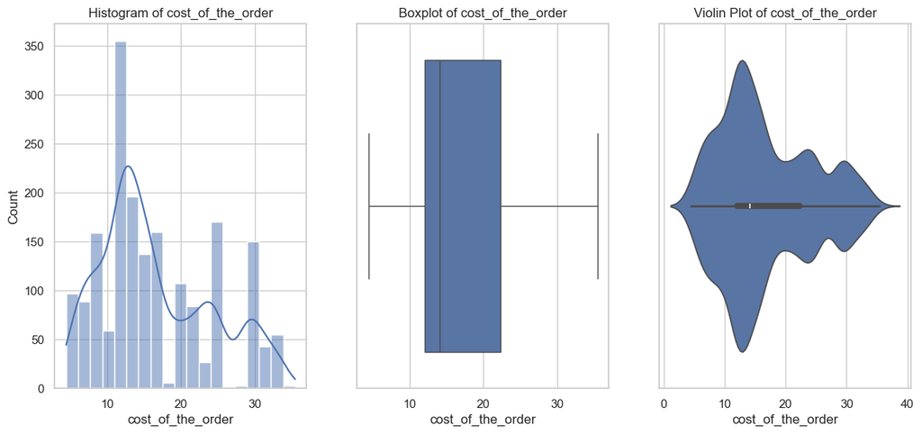

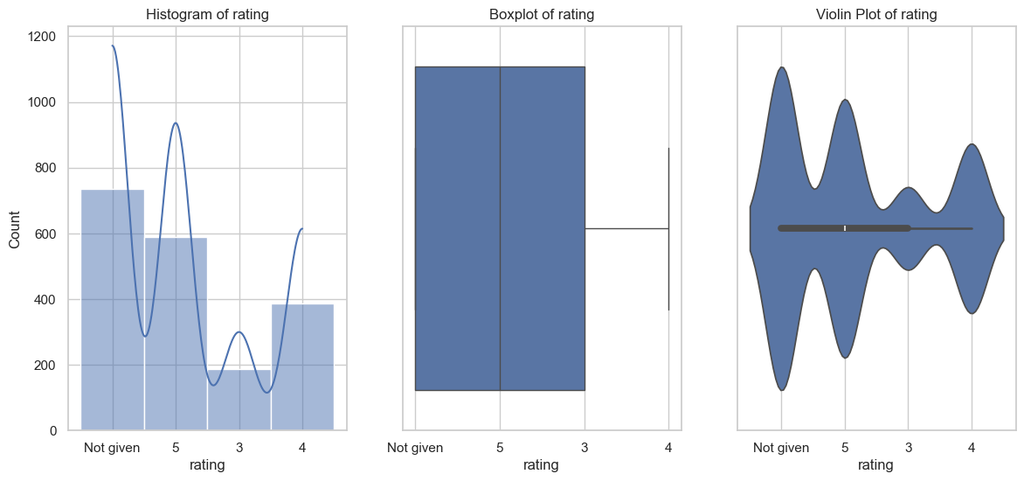

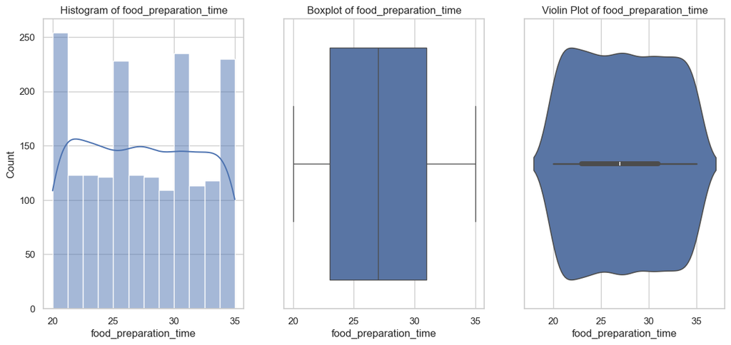

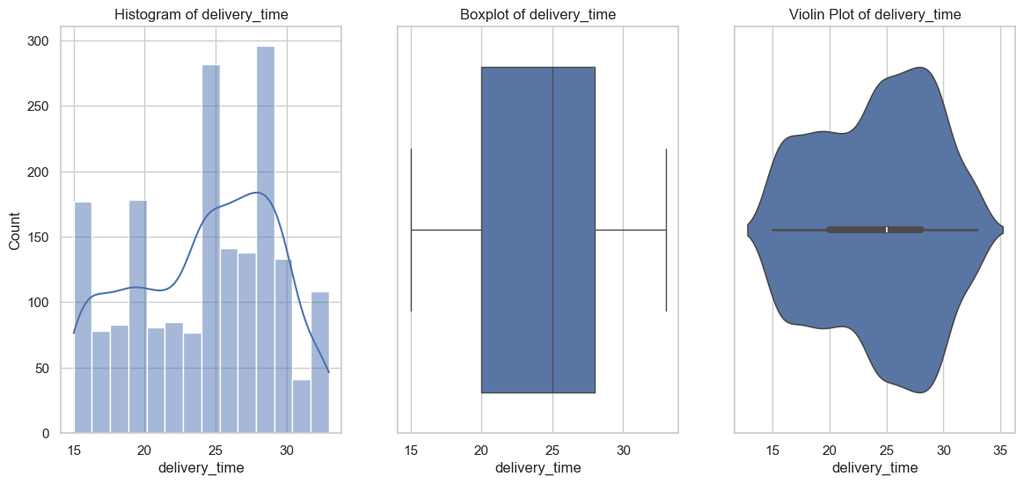

[figure not shown]

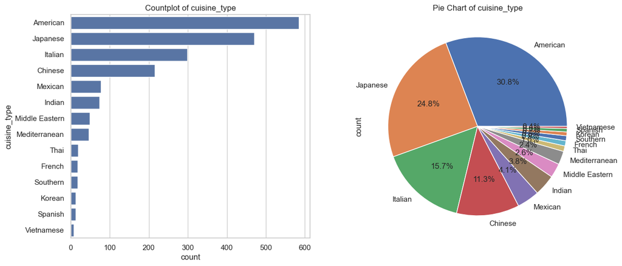

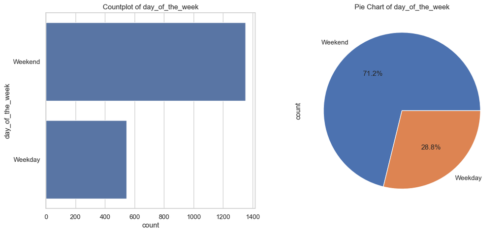

```python
# Set the aesthetic style of the plots
sns.set(style="whitegrid")

# 1. Visualize Numerical Variables
numerical_columns = ['cost_of_the_order', 'rating', 'food_preparation_time', 'delivery_time']

for column in numerical_columns:
    plt.figure(figsize=(14, 6))

    # Histogram
    plt.subplot(1, 3, 1)
    sns.histplot(df[column], kde=True)
    plt.title(f'Histogram of {column}')

    # Boxplot
    plt.subplot(1, 3, 2)
    sns.boxplot(x=df[column])
    plt.title(f'Boxplot of {column}')

    # Violin Plot
    plt.subplot(1, 3, 3)
    sns.violinplot(x=df[column])
    plt.title(f'Violin Plot of {column}')

    #plt.show()

# 2. Visualize Categorical Variables
categorical_columns = ['restaurant_name', 'cuisine_type', 'day_of_the_week']

for column in categorical_columns:
    plt.figure(figsize=(14, 6))

    # Countplot
    plt.subplot(1, 2, 1)
    sns.countplot(y=df[column], order=df[column].value_counts().index)
    plt.title(f'Countplot of {column}')

    # Pie Chart
    plt.subplot(1, 2, 2)
    df[column].value_counts().plot.pie(autopct='%1.1f%%')
    plt.title(f'Pie Chart of {column}')

    plt.show()
```

### **Question 7**: Which are the top 5 restaurants in terms of the number of orders received? [1 mark]

```python
# Count the number of orders for each restaurant
restaurant_order_counts = df['restaurant_name'].value_counts()

# Get the top 5 restaurants
top_5_restaurants = restaurant_order_counts.head(5)

print("Top 5 restaurants in terms of the number of orders received:")
print(top_5_restaurants)
```

```
Top 5 restaurants in terms of the number of orders received:
restaurant_name
Shake Shack                  219
The Meatball Shop            132
Blue Ribbon Sushi            119
Blue Ribbon Fried Chicken     96
Parm                          68
Name: count, dtype: int64
```

#### Observations:

Shake Shack is the most popular restaurant in terms of the number of orders received. There is a significant drop in the number of orders from the first to the fifth place, indicating a strong preference for certain restaurants. The top 5 restaurants offer a variety of cuisines, suggesting a diverse range of customer preferences.

### **Question 8**: Which is the most popular cuisine on weekends? [1 mark]

```python
# Filter the dataset for orders placed on weekends
weekend_data = df[df['day_of_the_week'] == 'Weekend']

# Count the number of orders for each cuisine type on weekends
weekend_cuisine_counts = weekend_data['cuisine_type'].value_counts()

# Get the most popular cuisine on weekends
most_popular_cuisine_weekends = weekend_cuisine_counts.idxmax()
most_popular_cuisine_count = weekend_cuisine_counts.max()

print(f"The most popular cuisine on weekends is: {most_popular_cuisine_weekends} with {most_popular_cuisine_count} orders.")
```

```
The most popular cuisine on weekends is: American with 415 orders.
```

### **Question 9**: What percentage of the orders cost more than 20 dollars? [2 marks]

```python
# Calculate the total number of orders
total_orders = len(df)

# Calculate the number of orders that cost more than 20 dollars
orders_above_20 = len(df[df['cost_of_the_order'] > 20])

# Calculate the percentage of orders that cost more than 20 dollars
percentage_above_20 = (orders_above_20 / total_orders) * 100

print(f"Percentage of orders that cost more than 20 dollars: {percentage_above_20:.2f}%")
```

```
Percentage of orders that cost more than 20 dollars: 29.24%
```

#### Observations:

Nearly a third of all orders (29.24%) cost more than 20 dollars. This could suggest that customers are willing to spend a significant amount on their orders. Depending on the context, this could indicate a high average order value, which could be beneficial for the profitability of the restaurants. However, it could also suggest that the prices are relatively high, which could be a barrier for some customers.e.

### **Question 10**: What is the mean order delivery time? [1 mark]

```python
# Calculate the mean order delivery time
mean_delivery_time = df['delivery_time'].mean()

print(f"The mean order delivery time is: {mean_delivery_time:.2f} minutes")
```

```
The mean order delivery time is: 24.16 minutes
```

#### Observations:

Average Delivery Time: The average time it takes for an order to be delivered is around 24 minutes. Customer Satisfaction: If this delivery time is within the acceptable range for your customers, it could indicate a high level of customer satisfaction with the delivery process. Potential for Improvement: However, if this delivery time is considered long, it might suggest areas for improvement in the delivery process. Outliers: It's also important to note that the mean can be influenced by extremely high or low values (outliers). If there are orders with exceptionally long or short delivery times, they could be skewing the mean. Further analysis could be done to identify and understand these outliers.

### **Question 11:** The company has decided to give 20% discount vouchers to the top 3 most frequent customers. Find the IDs of these customers and the number of orders they placed. [1 mark]

```python
# Count the number of orders for each customer
customer_order_counts = df['customer_id'].value_counts()

# Get the top 3 most frequent customers
top_3_customers = customer_order_counts.head(3)

print("Top 3 most frequent customers and the number of orders they placed:")
print(top_3_customers)
```

```
Top 3 most frequent customers and the number of orders they placed:
customer_id
52832    13
47440    10
83287     9
Name: count, dtype: int64
```

#### Observations:

The most frequent customer (ID: 52832) placed 13 orders, which is a relatively high number. This could suggest that this customer is highly satisfied with the service. The second and third most frequent customers also placed a significant number of orders (10 and 9 orders, respectively), indicating that they are also regular customers. Depending on the total number of customers and orders, these top 3 customers could represent a significant proportion of the customer base and sales.

### **Question 12**: Perform a multivariate analysis to explore relationships between the important variables in the dataset. (It is a good idea to explore relations between numerical variables as well as relations between numerical and categorical variables) [10 marks]

```
   order_id  customer_id            restaurant_name cuisine_type  \
0   1477147       337525                    Hangawi       Korean
1   1477685       358141  Blue Ribbon Sushi Izakaya     Japanese
2   1477070        66393                Cafe Habana      Mexican
3   1477334       106968  Blue Ribbon Fried Chicken     American
4   1478249        76942           Dirty Bird to Go     American

   cost_of_the_order day_of_the_week     rating  food_preparation_time  \
0              30.75         Weekend  Not given                     25
1              12.08         Weekend  Not given                     25
2              12.23         Weekday          5                     23
3              29.20         Weekend          3                     25
4              11.59         Weekday          4                     25

   delivery_time
0             20
1             23
2             28
3             15
4             24
0         NaN
1    4.333333
2    5.000000
3    3.000000
4    4.000000
Name: rating, dtype: float64
```

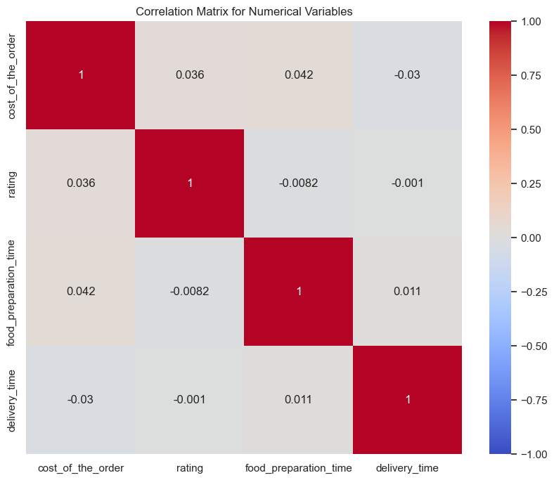

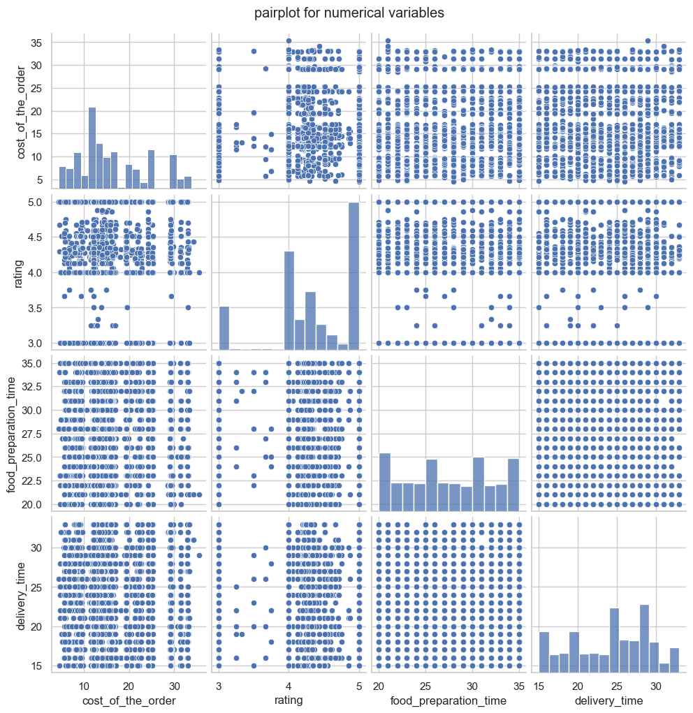

[figure not shown]

[figure not shown]

[figure not shown]

[figure not shown]

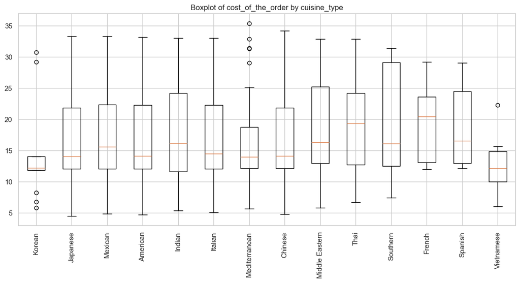

[figure not shown]

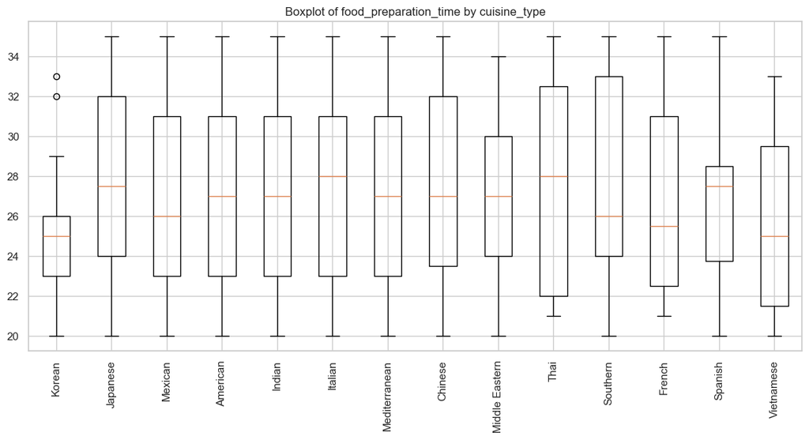

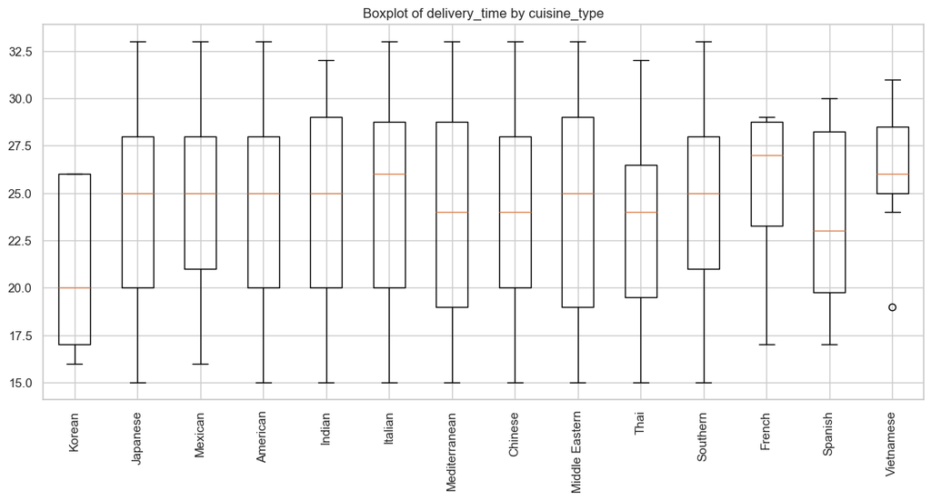

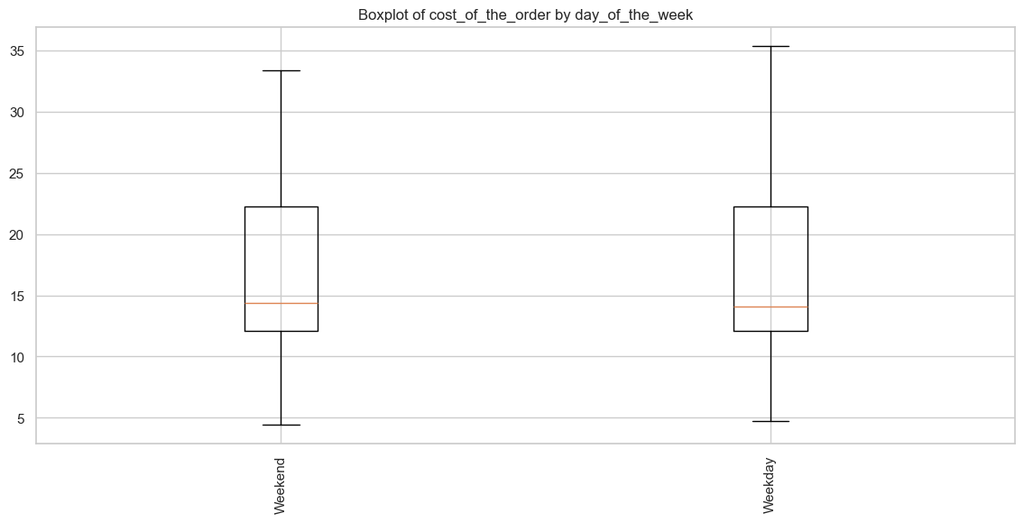

[figure not shown]

[4 more figures not shown]

```python
# first solution for "Not given"
print(df.head())
# Step 1: Replace 'Not given' with NaN
df['rating'] = df['rating'].replace('not given', np.nan)

# step 2: convert the 'rating' column to numeric
df['rating'] = pd.to_numeric(df['rating'], errors='coerce')


# calculate q1 (25th percentile) and q3 (75th percentile)
q1 = df['rating'].quantile(0.25)
q3 = df['rating'].quantile(0.75)
iqr = q3 - q1

# define the lower and upper bounds for outliers
lower_bound = q1 - 1.5 * iqr
upper_bound = q3 + 1.5 * iqr

# identify outliers
outliers = df[(df['rating'] < lower_bound) | (df['rating'] > upper_bound)]

# optionally, remove outliers
# df = df[~((df['rating'] < lower_bound) | (df['rating'] > upper_bound))]

# step 3: calculate the mean rating for each restaurant
restaurant_mean_ratings = df.groupby('restaurant_name')['rating'].mean()

# step 4: fill nan values with the mean rating of the respective restaurant
df['rating'] = df.apply(
    lambda row: restaurant_mean_ratings[row['restaurant_name']] if pd.isna(row['rating']) else row['rating'],
    axis=1
)
####################################################################

# Verify the changes
print(df['rating'].head())

# Set the aesthetic style of the plots
sns.set(style="whitegrid")

# 1. Correlation Matrix for Numerical Variables
numerical_columns = ['cost_of_the_order', 'rating', 'food_preparation_time', 'delivery_time']
correlation_matrix = df[numerical_columns].corr()

plt.figure(figsize=(10, 8))
sns.heatmap(correlation_matrix, annot=True, cmap='coolwarm', vmin=-1, vmax=1)
plt.title('Correlation Matrix for Numerical Variables')
plt.show()

# 2. pairplot for numerical variables
sns.pairplot(df[numerical_columns])
plt.suptitle('pairplot for numerical variables', y=1.02)
plt.show()

# # 3. boxplots for numerical vs. categorical variables
categorical_columns = ['restaurant_name', 'cuisine_type', 'day_of_the_week']
 # Clear the figure to avoid memory issues

for cat_col in categorical_columns:
    for num_col in numerical_columns:
        fig = plt.figure(figsize=(14, 6))
        plt.boxplot([df[df[cat_col] == cat][num_col] for cat in df[cat_col].unique()], labels=df[cat_col].unique())
        plt.title(f'Boxplot of {num_col} by {cat_col}')
        plt.xticks(rotation=90)
        plt.show()
        #plt.clf()


# 5. multivariate plots
# example: scatter plot with hue
plt.figure(figsize=(14, 6))
sns.scatterplot(x='cost_of_the_order', y='delivery_time', hue='cuisine_type', data=df)
plt.title('scatter plot of cost of the order vs. delivery time by cuisine type')
plt.show()

# example: violin plot
plt.figure(figsize=(14, 6))
sns.violinplot(x='day_of_the_week', y='cost_of_the_order', hue='cuisine_type', data=df, split=True)
plt.title('violin plot of cost of the order by day of the week and cuisine type')
plt.show()
```

### **Question 13:** The company wants to provide a promotional offer in the advertisement of the restaurants. The condition to get the offer is that the restaurants must have a rating count of more than 50 and the average rating should be greater than 4. Find the restaurants fulfilling the criteria to get the promotional offer. [3 marks]

```python
# Group by restaurant and calculate rating count and average rating
restaurant_stats = df.groupby('restaurant_name')['rating'].agg(['count', 'mean'])

# Filter restaurants that meet the criteria
promotional_restaurants = restaurant_stats[(restaurant_stats['count'] > 50) & (restaurant_stats['mean'] > 4)]

# Display the restaurants that qualify for the promotional offer
print(promotional_restaurants)
```

```
                           count      mean
restaurant_name
Blue Ribbon Fried Chicken     96  4.328125
Blue Ribbon Sushi            119  4.219178
Parm                          68  4.128205
RedFarm Broadway              59  4.243902
RedFarm Hudson                55  4.176471
Shake Shack                  219  4.278195
The Meatball Shop            132  4.511905
```

### **Question 14:** The company charges the restaurant 25% on the orders having cost greater than 20 dollars and 15% on the orders having cost greater than 5 dollars. Find the net revenue generated by the company across all orders. [3 marks]

```python
# Change the data type of 'charge' column to float
df['charge'] = df['charge'].astype(float)

# Define the conditions and corresponding charges
df.loc[df['cost_of_the_order'] > 20, 'charge'] = df['cost_of_the_order'] * 0.25
df.loc[(df['cost_of_the_order'] > 5) & (df['cost_of_the_order'] <= 20), 'charge'] = df['cost_of_the_order'] * 0.15

# Calculate the total revenue
total_revenue = df['charge'].sum()

# Display the total revenue
print(f'The net revenue generated by the company is ${total_revenue:.2f}')
```

[output not shown]

#### Observations:

The company has generated a significant amount of revenue ($6166.30) from the charges. The revenue is generated based on a tiered charging system, where orders with a higher cost have a higher charge rate. This tiered charging system could be a significant factor in the company's revenue generation strategy.

### **Question 15:** The company wants to analyze the total time required to deliver the food. What percentage of orders take more than 60 minutes to get delivered from the time the order is placed? (The food has to be prepared and then delivered.) [2 marks]

```python
# Calculate the total time required for each order
df['total_time'] = df['food_preparation_time'] + df['delivery_time']
# Count the number of orders that take more than 60 minutes
orders_over_60_minutes = df[df['total_time'] > 60].shape[0]
# Calculate the total number of orders
total_orders = df.shape[0]

# Calculate the percentage of orders taking more than 60 minutes
percentage_over_60_minutes = (orders_over_60_minutes / total_orders) * 100

# Display the percentage
print(f'The percentage of orders that take more than 60 minutes to get delivered is {percentage_over_60_minutes:.2f}%')
```

```
The percentage of orders that take more than 60 minutes to get delivered is 10.54%
```

#### Observations:

A relatively small percentage (10.54%) of orders take more than 60 minutes to get delivered. This suggests that the majority of orders are delivered in a timely manner, which could contribute to customer satisfaction. However, there is still a portion of orders that take longer than 60 minutes to deliver. This could be an area for improvement in the delivery process to enhance customer experience.

### **Question 16:** The company wants to analyze the delivery time of the orders on weekdays and weekends. How does the mean delivery time vary during weekdays and weekends? [2 marks]

```python
# Calculate the mean delivery time for weekdays and weekends
mean_delivery_time = df.groupby('day_of_the_week')['delivery_time'].mean()

# Display the mean delivery times
print(mean_delivery_time)

# Print the comparison of mean delivery times
weekday_mean = mean_delivery_time['Weekday']
weekend_mean = mean_delivery_time['Weekend']

print(f"The mean delivery time on weekdays is {weekday_mean:.2f} minutes.")
print(f"The mean delivery time on weekends is {weekend_mean:.2f} minutes.")
```

```
day_of_the_week
Weekday    28.340037
Weekend    22.470022
Name: delivery_time, dtype: float64
The mean delivery time on weekdays is 28.34 minutes.
The mean delivery time on weekends is 22.47 minutes.
```

### Conclusion and Recommendations

### **Question 17:** What are your conclusions from the analysis? What recommendations would you like to share to help improve the business? (You can use cuisine type and feedback ratings to drive your business recommendations.) [6 marks]

### Conclusions:

- Popularity and Reliability of Restaurants: Restaurants with high ratings and a large number of reviews are likely to be popular and reliable. These restaurants could be the main drivers of the business.

### Recommendations:

- Promote High-Rated Restaurants: The company could provide promotional offers or highlight these restaurants in the app to attract more customers.